# CFRM 502, Winter 2020

# Instructor: Bahman Angoshtari

# Solution to Homework 1

$\newcommand\Fc{\mathscr{F}}$ $\newcommand{\eps}{\varepsilon}$ $\newcommand{\Var}{\operatorname{Var}}$ $\newcommand\Cov{\operatorname{Cov}}$ $\newcommand\Corr{\operatorname{Corr}}$ $\newcommand{\sig}{\sigma}$ $\newcommand\Sig{\Sigma}$ $\newcommand{\al}{\alpha}$ $\newcommand{\gam}{\gamma}$ $\newcommand\Gam{\Gamma}$ $\newcommand\lam{\lambda}$ $\newcommand{\Del}{\Delta}$ $\newcommand\tht{\theta}$ $\newcommand\ph{\varphi}$ $\newcommand\om{\omega}$ $\newcommand\Om{\Omega}$ $\newcommand\rb{\bar{r}}$ $\newcommand{\Xb}{\bar{X}}$ $\newcommand{\Yb}{\bar{Y}}$ $\newcommand\Eb{\mathbb{E}}$ $\newcommand\Pb{\mathbb{P}}$ $\newcommand\Qb{\mathbb{Q}}$ $\newcommand\Rb{\mathbb{R}}$ $\newcommand\Zb{\mathbb{Z}}$ $\newcommand\Nb{\mathbb{N}}$ $\newcommand\Av{\textbf{A}}$ $\newcommand\Ev{\textbf{E}}$ $\newcommand\Dv{\textbf{D}}$ $\newcommand\Fv{\textbf{F}}$ $\newcommand\Gv{\textbf{G}}$ $\newcommand\Hv{\textbf{H}}$ $\newcommand\Kv{\textbf{K}}$ $\newcommand\Iv{\textbf{I}}$ $\newcommand\Pv{\textbf{P}}$ $\newcommand\Ov{\textbf{O}}$ $\newcommand\Sv{\textbf{S}}$ $\newcommand\Xv{\textbf{X}}$ $\newcommand\Yv{\textbf{Y}}$ $\newcommand\Zv{\textbf{Z}}$ $\newcommand\av{\mathbf{a}}$ $\newcommand\xv{\mathbf{x}}$ $\newcommand\yv{\mathbf{y}}$ $\newcommand\zv{\mathbf{z}}$ $\newcommand\Cv{\mathbf{C}}$ $\newcommand\mv{\mathbf{m}}$ $\newcommand\nv{\mathbf{n}}$ $\newcommand\pv{\mathbf{p}}$ $\newcommand\sv{\mathbf{s}}$ $\newcommand\wv{\mathbf{w}}$ $\newcommand\Wv{\textbf{W}}$ $\newcommand\alv{{\boldsymbol\al}}$ $\newcommand\betav{{\boldsymbol\beta}}$ $\newcommand\etav{{\boldsymbol\eta}}$ $\newcommand\epsv{{\boldsymbol\varepsilon}}$ $\newcommand\delv{{\boldsymbol\delta}}$ $\newcommand\Lamv{{\boldsymbol\Lambda}}$ $\newcommand\lamv{{\boldsymbol\lambda}}$ $\newcommand\muv{{\boldsymbol\mu}}$ $\newcommand\piv{{\boldsymbol\pi}}$ $\newcommand\Piv{{\boldsymbol\Pi}}$ $\newcommand\Gamv{{\boldsymbol\Gam}}$ $\newcommand\Phiv{{\boldsymbol\Phi}}$ $\newcommand\Sigv{{\boldsymbol\Sig}}$ $\newcommand\ah{\widehat{a}}$ $\newcommand\Pbh{\widehat{\Pb}}$ $\newcommand\phh{\widehat{\varphi}}$ $\newcommand\Ebh{\widehat{\Eb}}$ $\newcommand\Qh{\widehat{Q}}$ $\newcommand\Ih{\widehat{I}}$ $\newcommand\rh{\widehat{r}}$ $\newcommand\pih{\widehat{\pi}}$ $\newcommand\Pih{\widehat{\Pi}}$ $\newcommand\Sigvh{\widehat{\Sigv}}$ $\newcommand\Wh{\widehat{W}}$ $\newcommand\Fh{\widehat{F}}$ $\newcommand\Yh{\widehat{Y}}$ $\newcommand\Zh{\widehat{Z}}$ $\newcommand\Yvh{\widehat{\Yv}}$ $\newcommand\Ah{\widehat{\Ac}}$ $\newcommand\uh{\widehat{u}}$ $\newcommand\vh{\widehat{v}}$ $\newcommand\fh{\widehat{f}}$ $\newcommand\hh{\widehat{h}}$ $\newcommand\Bh{\widehat{B}}$ $\newcommand\Ovh{\widehat{\Ov}}$ $\newcommand\Xvh{\widehat{\Xv}}$ $\newcommand\rhoh{\widehat{\rho}}$ $\newcommand\nuh{\widehat{\nu}}$ $\newcommand\varphih{\widehat{\varphi}}$ $\newcommand\alh{\widehat{\al}}$ $\newcommand\thetah{\widehat{\theta}}$ $\newcommand\betah{\widehat{\beta}}$ $\newcommand\betavh{\widehat{\boldsymbol\beta}}$ $\newcommand\kaph{\widehat{\kappa}}$ $\newcommand\sigh{\widehat{\sigma}}$ $\newcommand\epsh{\widehat{\eps}}$ $\newcommand\epsvh{\widehat{\epsv}}$ $\newcommand\epst{\widetilde{\eps}}$ $\newcommand\muh{\widehat{\mu}}$ $\newcommand\dd{\mathrm{d}}$ $\newcommand\ee{\mathrm{e}}$ $\newcommand{\var}[1]{\text{Var} \left( #1 \right)}$

The following code sets up graphics in the Juypter notebook.

```r
# Configuring plots in the Jupyter notebook
options(repr.plot.pointsize = 20, # Text height in pt
        repr.plot.bg        = 'white',
        repr.plot.antialias = 'gray',
        #jpeg quality bumped from default
        repr.plot.quality   = 90,
        #vector font family
        repr.plot.family    = 'serif') # Vector font family. 'sans', 'serif', 'mono' or a specific one
```

# 1.

Consider the daily prices of Caterpillar stock (CAT), Procter&Gamble stock (PG), and Dow Jones Industrial Average (^DJI) from January 3, 2007 to December 31, 2018.

## (a)

Provide a candlestick plot for each of the three time series.

**Solution:**

[output not shown]

1. 'CAT'

2. 'PG'

3. '^DJI'

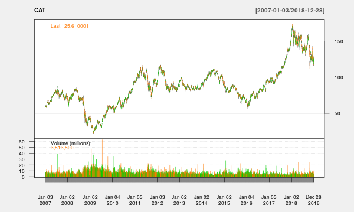

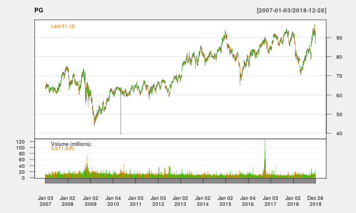

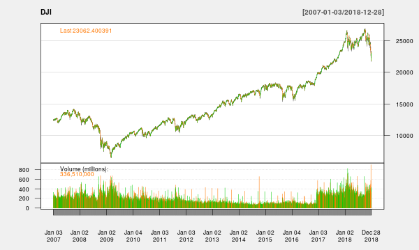

```r
library(quantmod)
getSymbols(c("CAT", "PG", "^DJI"), from="2007-01-03", to="2018-12-30", src="yahoo")
# Configuring the plot size in the Jupyter notebook
sc = 1.2;options(repr.plot.width=10*sc, repr.plot.height=6*sc,
               repr.plot.res = 50)
chartSeries(CAT, theme="white")
chartSeries(PG, theme="white")
chartSeries(DJI, theme="white")
```

## (b)

Calculate the net daily returns for the three prices. Find basic statistics for the sample returns, namely the sample mean, standard deviation, minimum and maximum, median, and 1st and 3rd quartiles of each return series.

Hint: You may find the function `basicStats()` of the R package `fBasics` useful.

**Solution:** First, we compute the net returns. Note that we have use the adjusted prices.

```r
CAT.netret = diff(CAT$CAT.Adjusted)/lag(CAT$CAT.Adjusted)
PG.netret = diff(PG$PG.Adjusted)/lag(PG$PG.Adjusted)
DJI.netret = diff(DJI$DJI.Adjusted)/lag(DJI$DJI.Adjusted)
```

We can then obtain the descriptive statistic as follows.

```r
summary(CAT.netret)
summary(PG.netret)
summary(DJI.netret)
```

```
     Index             CAT.Adjusted
 Min.   :2007-01-03   Min.   :-0.1143394
 1st Qu.:2009-12-30   1st Qu.:-0.0088098
 Median :2012-12-31   Median : 0.0005114
 Mean   :2012-12-30   Mean   : 0.0005624
 3rd Qu.:2015-12-29   3rd Qu.: 0.0103844
 Max.   :2018-12-28   Max.   : 0.1472296
                      NA's   :1
```

```
     Index             PG.Adjusted
 Min.   :2007-01-03   Min.   :-0.0789710
 1st Qu.:2009-12-30   1st Qu.:-0.0045649
 Median :2012-12-31   Median : 0.0002516
 Mean   :2012-12-30   Mean   : 0.0002951
 3rd Qu.:2015-12-29   3rd Qu.: 0.0053885
 Max.   :2018-12-28   Max.   : 0.1021440
                      NA's   :1
```

```
     Index             DJI.Adjusted
 Min.   :2007-01-03   Min.   :-0.0787328
 1st Qu.:2009-12-30   1st Qu.:-0.0039911
 Median :2012-12-31   Median : 0.0005503
 Mean   :2012-12-30   Mean   : 0.0002708
 3rd Qu.:2015-12-29   3rd Qu.: 0.0052395
 Max.   :2018-12-28   Max.   : 0.1108033
                      NA's   :1
```

To obtain standard deviations, we may use the function `sd()`

```r
sd(CAT.netret, na.rm=TRUE)
sd(PG.netret, na.rm=TRUE)
sd(DJI.netret, na.rm=TRUE)
```

0.0203540528706837

0.0110004991053658

0.0115923324203556

A better estimate for standard deviation can be obtained by the median absolute deviations (MAD), as follows.

```r
mad(CAT.netret, na.rm=TRUE)
mad(PG.netret, na.rm=TRUE)
mad(DJI.netret, na.rm=TRUE)
```

0.0141868131642459

0.0074072610353959

0.00688186860481135

## (c)

Are the **log returns** of the prices normally distributed? Justify your answer by an appropriate test or graph.

**Solution:** First, we calculate the log returns.

```r
CAT.logret = diff(log(CAT$CAT.Adjusted))
PG.logret = diff(log(PG$PG.Adjusted))
DJI.logret = diff(log(DJI$DJI.Adjusted))
```

The normal probability plots indicate that the log-return are not normal and have heavy tails.

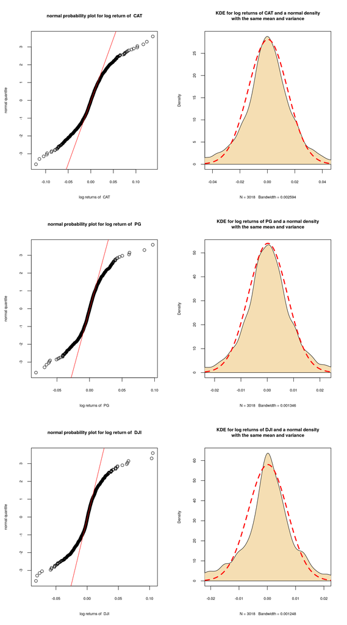

```r
logrets = list(CAT.logret, PG.logret, DJI.logret)
labels = list("CAT", "PG", "DJI")
par(mfrow=c(3,2))
# Configuring the plot size in the Jupyter notebook
sc = 1;options(repr.plot.width=10*sc, repr.plot.height=18*sc,
               repr.plot.res       = 200)
for (i in 1:length(logrets)) {
  retn = coredata(logrets[[i]])
  qqnorm(retn, datax = TRUE,
         xlab = "normal quantile", # this is for the theoretical quantiles
         ylab = paste("log returns of ", labels[[i]]), # this is for the sample quantiles
         main = paste("normal probability plot for log return of ", labels[[i]]))
  qqline(retn, datax=TRUE, col = 2)
  d <- density(retn, adjust = 1, na.rm = TRUE)
  m=mean(retn, na.rm=TRUE)
  stdv = mad(retn, na.rm=TRUE)
  plot(d, type = "n", xlim=c(m-3*stdv,m+3*stdv),
       main= paste("KDE for log returns of", labels[[i]], "and a normal density\nwith the same mean and variance"))
  polygon(d, col = "wheat")
  z = seq(from=m-5*stdv,to=m+5*stdv,by=stdv/100)
  lines(z,dnorm(z,mean=m, sd=stdv), lty=2,lwd=3,col="red")
}
```

Alternatively, one can conduct a the tests of normality as explained in section 4.4 of the textbook. The result would reject normality.

**Note:** Either using a normal probability plot, or a normality test is enough for getting the full points.

## (d)

Find a t-distribution that is a good fit for the marginal distribution of each **log return** series. You must justify your answer by appropriate graphs.

**Solution:** The t-probability plots indicate a df=4 (or df=3) t-distribution for CAT and a df=3 t-distribution for PG and DJI. You should find a t-plot that is most linear.

**Note:** Using non-integer degree of freedom (say df=3.5) is allowed, however is not necessary for getting a full point.

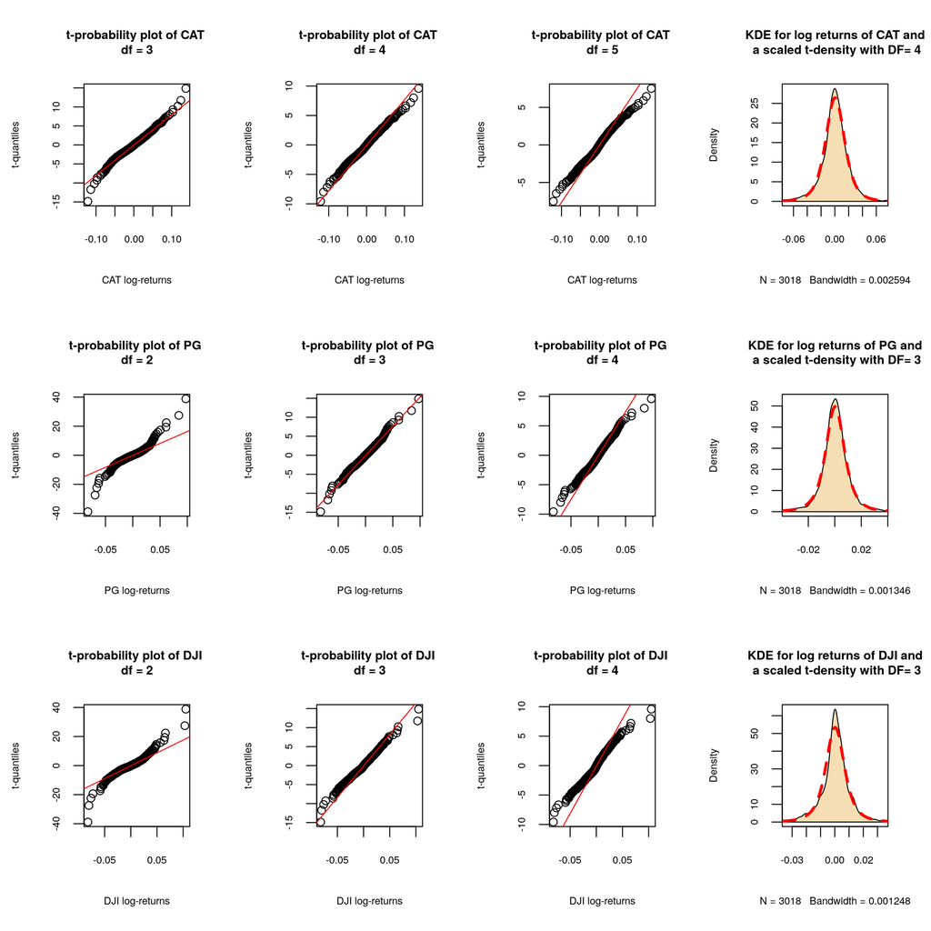

```r
# Configuring the plot size in the Jupyter notebook
sc = 1;options(repr.plot.width=10*sc, repr.plot.height=10*sc,
               repr.plot.res       = 200)
par(mfrow=c(3,4))
logrets = list(CAT.logret, PG.logret, DJI.logret)
labels = list("CAT", "PG", "DJI")
tdfs = c(3,2,2)
for (i in 1:length(logrets)) {
  retn = coredata(logrets[[i]])
  n = length(retn)
  grid = (1:n)/(n+1)
  for (tdf in tdfs[[i]]:(tdfs[[i]]+2)) {
    qqplot(retn, qt(grid,df=tdf),
           main= paste("t-probability plot of", labels[[i]], "\ndf =", tdf),
           xlab=paste(labels[[i]], "log-returns"),
           ylab="t-quantiles")
    qntl = quantile(retn, probs = c(0.25,0.75), na.rm=TRUE, names=FALSE)
    abline( lm( qt(c(.25,.75),df = tdf) ~ qntl ), col = 2)
  }
  d <- density(retn, adjust = 1, na.rm = TRUE)
  m=mean(retn, na.rm=TRUE)
  stdv = mad(retn, na.rm=TRUE)
  plot(d, type = "n", xlim=c(m-5*stdv,m+5*stdv),
       main= paste("KDE for log returns of", labels[[i]], "and\n a scaled t-density with DF=", tdfs[[i]]+1))
  polygon(d, col = "wheat")
  x = seq(from=m-10*stdv,to=m+10*stdv,by=stdv/100)
  lines(x,dt((x-m)/stdv,df=tdfs[[i]]+1)/stdv, lty=2,lwd=3,col="red")
}
```

**Note:** We may also use the R function `fitdistr()` to fit a t distribution to the data. This is done in the following code. The results suggest 2.95, 2.97, and 2.40 degrees of freedom for CAT, PG, and DJI, respectively. This is consistent with what we found by the graphs.

```r
library(MASS)
df=c(0,0,0)
for (i in 1:length(logrets)) {
  retn = na.omit(logrets[[i]])
  suppressWarnings(df[i] <- fitdistr(retn,"t")$estimate[['df']])
}
list(CAT=df[1], PG=df[2], DJI=df[3])
```

**$CAT**

2.95948922148998

**$PG**

2.97308041736069

**$DJI**

2.39760816958653

# 2.

## (a)

Consider 5 samples named $EE$, $TT$, $XX$, $YY$, and $ZZ$. The following 4 graphs are Q--Q plots. The top two are normal probability plots of $YY$ and $ZZ$ samples, while the bottom two graphs are the quantiles of two samples. Give an interpretation to each of the Q--Q plots.

[figure not shown]

**Solution:**

**Top left plot:** YY is not normal, it has heavy tails (with respect to a normal distribution).

**Top right plot:** ZZ is not normal, its distribution is not symmetric and is skewed toward negative values (left-skewed).

**bottom left plot:** TT is skewed to the right with respect to XX. Equivalently, XX is left-skewed with respect to TT.

**bottom right plot:** TT is right-skewed with respect to EE. Equivalently, EE is left-skewed with respect to TT.

## (b)

Use the R command `rnorm` to create a sample of size N = 100 from the standard normal distribution and use Q-Q plots to assess the normality of the data. In other words, explain which features of the Q-Q plot you produce suggest that the data are from a Gaussian distribution and which don't.

**Solution:** The sample is clearly normal, since the normal probability plot is linear.

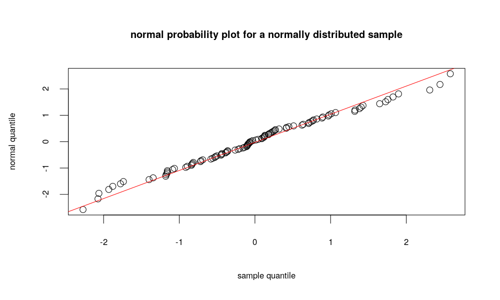

```r
# Configuring the plot size in the Jupyter notebook
sc = 1;options(repr.plot.width=10*sc, repr.plot.height=6*sc, repr.plot.res = 100)

par(mfrow=c(1,1))
set.seed(100)
normSample = rnorm(100)
qqnorm(normSample, datax = TRUE,
       xlab = "normal quantile", # this is for the theoretical quantiles
       ylab = "sample quantile", # this is for the sample quantiles
       main = "normal probability plot for a normally distributed sample")
qqline(normSample, datax=TRUE, col = 2)
```

## (c)

Repeat part (b) for a sample of size N=100 from the exponential distribution (with mean 1).

*Hint:* use the R function `rexp()`

**Solution:** Since the QQ plot is not linear, the sample clearly shows non-normality. Its concavity indicates that the sample is right-skewed.

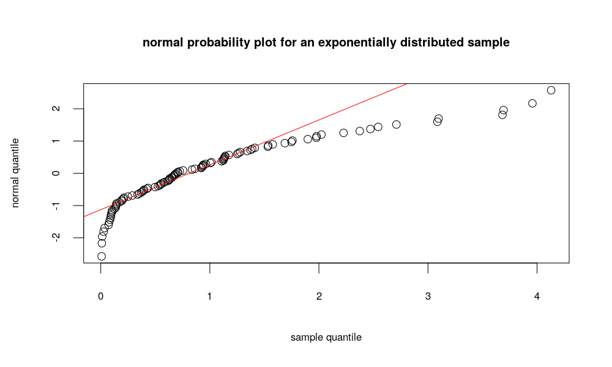

```r
# Configuring the plot size in the Jupyter notebook
sc = 1;options(repr.plot.width=10*sc, repr.plot.height=6*sc, repr.plot.res = 100)

set.seed(100);expSample = rexp(100)
qqnorm(expSample, datax = TRUE,
       xlab = "normal quantile", # this is for the theoretical quantiles
       ylab = "sample quantile", # this is for the sample quantiles
       main = "normal probability plot for an exponentially distributed sample")
qqline(expSample, datax=TRUE, col = 2)
```

## (d)

Draw a Q--Q plot of the sample in part (b) vs. the sample in part (c). Interpret the Q--Q plot.

**Solution:** In this case, the convexity of the QQ plot shows that the exponential sample (on the y-axis) is right-skewed compare to the normal sample (on the x-axis).

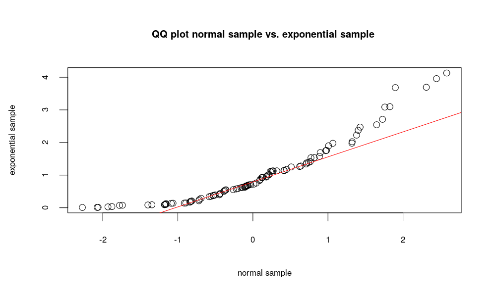

```r
qqplot(normSample, expSample,
       main= "QQ plot normal sample vs. exponential sample ",
       xlab="normal sample", ylab="exponential sample")
qntlnorm = quantile(normSample, probs = c(0.25,0.75), na.rm=TRUE, names=FALSE)
qntlexp = quantile(expSample, probs = c(0.25,0.75), na.rm=TRUE, names=FALSE)
abline( lm( qntlexp ~ qntlnorm ), col = 2)
```

# 3.

## (a)

For the line regression model $Y_i = \beta_0 + \beta_1 X_i + \eps_i$, find a formula for $\Var(\hat{\beta}_0|X_1,\dots,X_n)$.

*Hint:* You may use equation (9.8) on page 222 of the textbook.

**Solution:** We have shown that $\betah_1 = \sum_{i=1}^n w_i\,Y_i$, where $w_i = \frac{X_i-\Xb}{\sum_{j=1}^n (X_i-\Xb)^2}$. We have also shown that $\betah_0 = \Yb - \betah_1\,\Xb$. See pages 219 and 222 of the textbook. We then have

\begin{align*} \betah_0 = \Yb - \betah_1\,\Xb = \frac{1}{n}\sum_{i=1}^n Y_i - \Xb \sum_{i=1}^n w_i\,Y_i = \sum_{i=1}^n \left(\frac{1}{n} - \Xb\, w_i\right)\,Y_i. \end{align*}

Therefore,

\begin{align*} \var{\betah_0|X_1,\dots,X_n} &= \var{\sum_{i=1}^n \left(\frac{1}{n} - \Xb\, w_i\right)\,Y_i\Big|X_1,\dots,X_n}\\ &= \var{\sum_{i=1}^n \left(\frac{1}{n} - \Xb\, w_i\right)\,Y_i\Big|X_1,\dots,X_n}\\ &= \sum_{i=1}^n \left(\frac{1}{n} - \Xb\, w_i\right)^2\,\var{Y_i\Big|X_1,\dots,X_n}\\ &= \sig^2_\eps\sum_{i=1}^n \left(\frac{1}{n} - \Xb\, w_i\right)^2\\ &= \sig^2_\eps\sum_{i=1}^n \left(\frac{1}{n^2} + \Xb^2\, w_i^2 - 2 \frac{\Xb\,w_i}{n}\right)\\ &= \sig^2_\eps\,\left(\frac{1}{n} + \frac{\Xb^2}{\sum_{j=1}^n (X_i-\Xb)^2}\right) \end{align*}

Here, we have used the following results: $\sum_{i=1}^n w_i=0$, and $\sum_{i=1}^n w_i^2 = \frac{1}{\sum_{j=1}^n (X_i-\Xb)^2}$.

## (b)

Show equation (9.15) on page 228 of the textbook for the line regression model in part (a).

**Solution:** We have

\begin{align*} \text{total SS} &=\sum_{i=1}^n \left(Y_i - \Yb\right)^2\\ &= \sum_{i=1}^n \left(Y_i - \Yh_i + \Yh_i - \Yb\right)^2\\ &= \sum_{i=1}^n \left(Y_i - \Yh_i\right)^2 + \sum_{i=1}^n \left(\Yh_i - \Yb\right)^2 - 2 \sum_{i=1}^n \left(\Yh_i - \Yb\right)\left(Y_i - \Yh_i\right)\\ &= \text{residual SS} + \text{regression SS} - 2 \sum_{i=1}^n \left(\Yh_i - \Yb\right)\left(Y_i - \Yh_i\right). \end{align*}

To show the result, it suffices to show that $\sum_{i=1}^n \left(\Yh_i - \Yb\right)\left(Y_i - \Yh_i\right)=0$. Note that

\begin{align*} \sum_{i=1}^n \left(\Yh_i - \Yb\right)\left(Y_i - \Yh_i\right) = \underbrace{\sum_{i=1}^n \Yh_i\,\left(Y_i - \Yh_i\right)}_{\text{Sum 1}} -\Yb\,\underbrace{\sum_{i=1}^n \left(Y_i - \Yh_i\right)}_{\text{Sum 2}} \end{align*}

We show that both "Sum 1" and "Sum 2" in the equation above are zero. Since $\betah_0$ and $\betah_1$ are the minimizer of $f(\betah_0, \betah_1) = \sum_{i=1}^n \left(Y_i - \beta_0-\beta_1 X_i\right)^2$, by the first order derivative conditions, we must have

\begin{align*}\label{eq:beta0}\tag{$\star$} 0=\frac{\partial f}{\partial \beta_0}(\betah_0, \betah_1) = -2\sum_{i=1}^n \left(Y_i - \betah_0-\betah_1 X_i\right) = -2\sum_{i=1}^n \left(Y_i - \Yh_i\right). \end{align*}

Thus, Sum 2 = $\sum_{i=1}^n \left(Y_i - \Yh_i\right) = 0$. Furthermore,

\begin{align*}\label{eq:beta1}\tag{$\star\star$} 0=\frac{\partial f}{\partial \beta_1}(\betah_0, \betah_1) = -2\sum_{i=1}^n X_i\left(Y_i - \betah_0-\betah_1 X_i\right) = -2\sum_{i=1}^n X_i\left(Y_i - \Yh_i\right). \end{align*}

It then follows that

\begin{align*} \text{Sum 1} &= \sum_{i=1}^n \Yh_i\,\left(Y_i - \Yh_i\right) = \sum_{i=1}^n (\betah_0+\betah_1\,X_i)\left(Y_i - \Yh_i\right)\\ &= \betah_0\,\underbrace{\sum_{i=1}^n \left(Y_i - \Yh_i\right)}_{\text{by \eqref{eq:beta0} is 0}} + \betah_1\,\underbrace{\sum_{i=1}^n X_i\,\left(Y_i - \Yh_i\right)}_{\text{by \eqref{eq:beta1} is 0}} = 0 \end{align*}

We have proved that Sum 1 = Sum 2 = 0.